# ex2

# 1. SMSAs

## 1. inspect data

```r
url <- "http://stat.ethz.ch/Teaching/Datasets/mortality.csv"
mortality <- read.csv(url, header = TRUE)
mortality <- mortality[,-1]
```

use `splom()` in the lattice package to draw pairs plot:

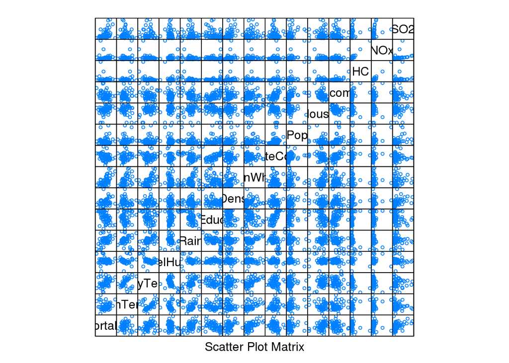

```r
library(lattice)
splom(~mortality, pscales=0, cex=0.5)
```

The response variable mortality versus the predictor variables is the last row of the plot.

As the Pop, HC, NOx, SO2 have skewed distributions, we log-transform them.

Now add log-transformation:

```r
mortality_old <- mortality
mortality[,"logPop"] <- log(mortality[,"Pop"])
mortality[,"logHC"] <- log(mortality[,"HC"])
mortality[,"logNOx"] <- log(mortality[,"NOx"])
mortality[,"logSO2"] <- log(mortality[,"SO2"])
col_num <- which( names(mortality) %in% c("Pop", "HC", "NOx", "SO2") )
mortality <- mortality[,-col_num]
```

Now the scatter plot looks better:

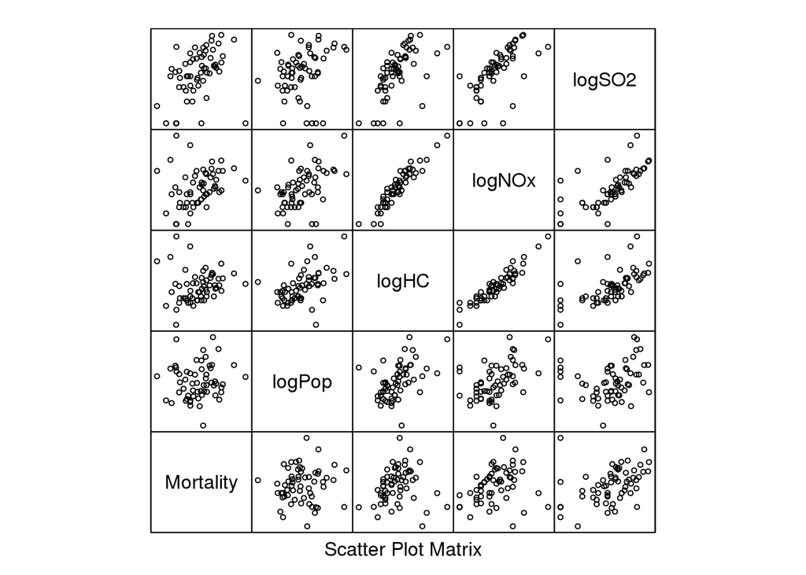

```r
splom(~mortality[,c("Mortality","logPop", "logHC", "logNOx", "logSO2")], pscales=0, cex=0.5, col="black")
```

Fit the data to linear model, fit the full model (i.e. use all predictor variables, starting point of backward selection):

```r
mortal.full <- lm(Mortality~. , data=mortality)
```

Fit the empty model (starting point of forward selection):

```r
mortal.empty <- lm(Mortality~1, data=mortality)
```

### Tukey-Anscombe plot: fitted-value VS residuals.

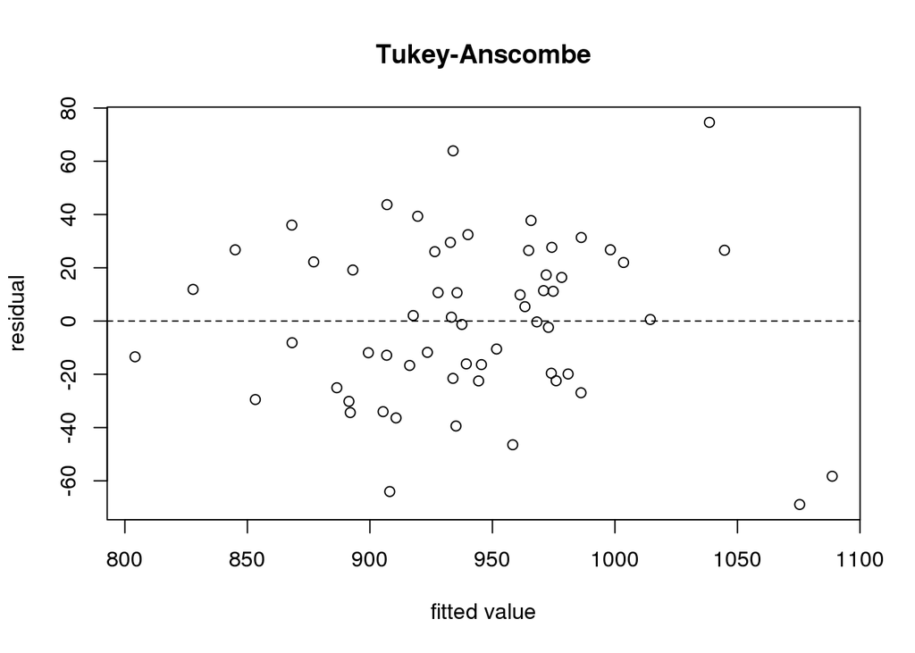

```r
plot(fitted(mortal.full), residuals(mortal.full),xlab="fitted value", ylab="residual", main="Tukey-Anscombe")
abline(h=0, lty=2)
```

### QQ plot: empirical quantile VS standard quantiles

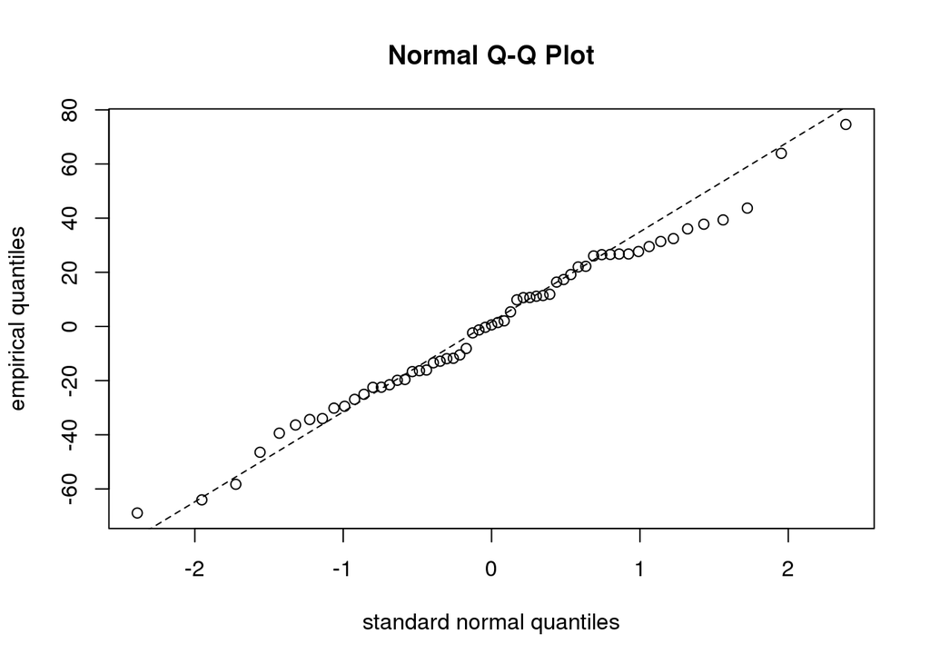

```r
qqnorm(resid(mortal.full), xlab="standard normal quantiles", ylab="empirical quantiles")
qqline(resid(mortal.full), lty=2)
```

look at the fitting summary:

```r
summary(mortal.full)
```

```
##
## Call:
## lm(formula = Mortality ~ ., data = mortality)
##
## Residuals:
##     Min      1Q  Median      3Q     Max
## -68.893 -20.704   0.586  24.129  74.604
##
## Coefficients:
##               Estimate Std. Error t value Pr(>|t|)
## (Intercept)  1.297e+03  2.934e+02   4.422 6.32e-05 ***
## JanTemp     -2.368e+00  8.851e-01  -2.676   0.0104 *
## JulyTemp    -1.752e+00  2.031e+00  -0.863   0.3931
## RelHum       3.420e-01  1.059e+00   0.323   0.7482
## Rain         1.493e+00  5.898e-01   2.532   0.0150 *
## Educ        -1.000e+01  9.087e+00  -1.101   0.2771
## Dens         4.525e-03  4.223e-03   1.072   0.2897
## NonWhite     5.152e+00  1.002e+00   5.143 6.01e-06 ***
## WhiteCollar -1.883e+00  1.198e+00  -1.572   0.1232
## House       -4.574e+01  3.939e+01  -1.161   0.2518
## Income      -6.892e-04  1.334e-03  -0.516   0.6081
## logPop       4.391e+00  7.714e+00   0.569   0.5721
## logHC       -2.204e+01  1.523e+01  -1.447   0.1550
## logNOx       3.397e+01  1.425e+01   2.384   0.0215 *
## logSO2      -3.687e+00  7.359e+00  -0.501   0.6189
## ---
## Signif. codes:  0 '***' 0.001 '**' 0.01 '*' 0.05 '.' 0.1 ' ' 1
##
## Residual standard error: 34.48 on 44 degrees of freedom
## Multiple R-squared:  0.7685, Adjusted R-squared:  0.6949
## F-statistic: 10.43 on 14 and 44 DF,  p-value: 8.793e-10
```

The summary statistic of the model reveals that only JanTemp, Tain, NonWhite, logNOx are significant on the response.

## 2. stepwise variable selection

### backward selection

```r
mortal.bw <- step(mortal.full, dir="backward")
```

```
## Start:  AIC=430.46
## Mortality ~ JanTemp + JulyTemp + RelHum + Rain + Educ + Dens +
##     NonWhite + WhiteCollar + House + Income + logPop + logHC +
##     logNOx + logSO2
##
##               Df Sum of Sq   RSS    AIC
## - RelHum       1     124.1 52436 428.60
## - logSO2       1     298.4 52611 428.80
## - Income       1     317.1 52629 428.82
## - logPop       1     385.2 52698 428.89
## - JulyTemp     1     884.5 53197 429.45
## - Dens         1    1365.3 53678 429.98
## - Educ         1    1440.1 53752 430.06
## - House        1    1603.0 53915 430.24
## <none>                     52312 430.46
## - logHC        1    2489.0 54801 431.20
## - WhiteCollar  1    2937.0 55249 431.68
## - logNOx       1    6759.6 59072 435.63
## - Rain         1    7622.0 59934 436.48
## - JanTemp      1    8512.6 60825 437.35
## - NonWhite     1   31446.0 83758 456.23
##
## Step:  AIC=428.6
## Mortality ~ JanTemp + JulyTemp + Rain + Educ + Dens + NonWhite +
##     WhiteCollar + House + Income + logPop + logHC + logNOx +
##     logSO2
##
##               Df Sum of Sq   RSS    AIC
## - Income       1       337 52774 426.98
## - logPop       1       405 52841 427.05
## - logSO2       1       454 52891 427.11
## - Dens         1      1326 53762 428.07
## - Educ         1      1474 53911 428.24
## - JulyTemp     1      1576 54012 428.35
## - House        1      1688 54124 428.47
## <none>                     52436 428.60
## - logHC        1      2468 54905 429.31
## - WhiteCollar  1      2934 55370 429.81
## - logNOx       1      6910 59346 433.90
## - Rain         1      8134 60571 435.11
```

[output cut: 99 more lines]

```
## - JanTemp      1     18282 75541 436.14
## - NonWhite     1     41479 98739 451.94
##
## Step:  AIC=421.7
## Mortality ~ JanTemp + Rain + Educ + NonWhite + WhiteCollar +
##     logNOx
##
##               Df Sum of Sq    RSS    AIC
## <none>                      59143 421.70
## - WhiteCollar  1      2194  61337 421.85
## - Educ         1      2621  61764 422.26
## - Rain         1     13263  72406 431.64
## - JanTemp      1     17593  76736 435.07
## - logNOx       1     20607  79750 437.34
## - NonWhite     1     48049 107192 454.79
```

### forward selection

```r
motal.fw <- step(mortal.empty, dir="forward", scope = list(upper=mortal.full,lower=mortal.empty))
```

```
## Start:  AIC=488.79
## Mortality ~ 1
##
##               Df Sum of Sq    RSS    AIC
## + NonWhite     1     94473 131520 458.85
## + Educ         1     58340 167652 473.17
## + Rain         1     42393 183599 478.54
## + logSO2       1     34675 191318 480.97
## + House        1     30608 195385 482.21
## + JulyTemp     1     23407 202586 484.34
## + WhiteCollar  1     18920 207072 485.63
## + Income       1     18138 207855 485.86
## + logNOx       1     17696 208296 485.98
## + Dens         1     14365 211627 486.92
## <none>                     225993 488.79
## + logHC        1      3553 222440 489.86
## + RelHum       1      2309 223684 490.19
## + logPop       1      1646 224347 490.36
## + JanTemp      1        58 225935 490.78
##
## Step:  AIC=458.85
## Mortality ~ NonWhite
##
##               Df Sum of Sq    RSS    AIC
## + Educ         1     32883  98637 443.88
## + logSO2       1     28954 102566 446.18
## + JanTemp      1     28033 103487 446.71
## + Dens         1     14871 116649 453.77
## + WhiteCollar  1     14438 117082 453.99
## + Rain         1     14017 117503 454.20
## + Income       1     10865 120655 455.77
## + House        1      5055 126464 458.54
## + logNOx       1      4980 126540 458.58
## <none>                     131520 458.85
## + JulyTemp     1      1618 129902 460.12
## + logPop       1       855 130664 460.47
## + logHC        1       204 131316 460.76
## + RelHum       1       131 131389 460.79
##
## Step:  AIC=443.88
```

[output cut: 90 more lines]

```
## + JulyTemp  1     69.42 59067 425.62
## + Income    1     30.47 59105 425.66
##
## Step:  AIC=423.59
## Mortality ~ NonWhite + Educ + logSO2 + JanTemp + Rain + logNOx +
##     WhiteCollar + House
##
##            Df Sum of Sq   RSS    AIC
## <none>                  57067 423.59
## + logHC     1   1635.68 55431 423.88
## + Dens      1   1251.25 55816 424.28
## + logPop    1    424.15 56643 425.15
## + RelHum    1    184.44 56882 425.40
## + JulyTemp  1    105.41 56961 425.48
## + Income    1     71.05 56996 425.52
```

### all-subsets regression

Both fw and bw are greedy algorithms, in each step it adds variables and never deletes them, although an addition of a new variable may render one or more of the already added variables non-significant.

Use the `leaps` package.

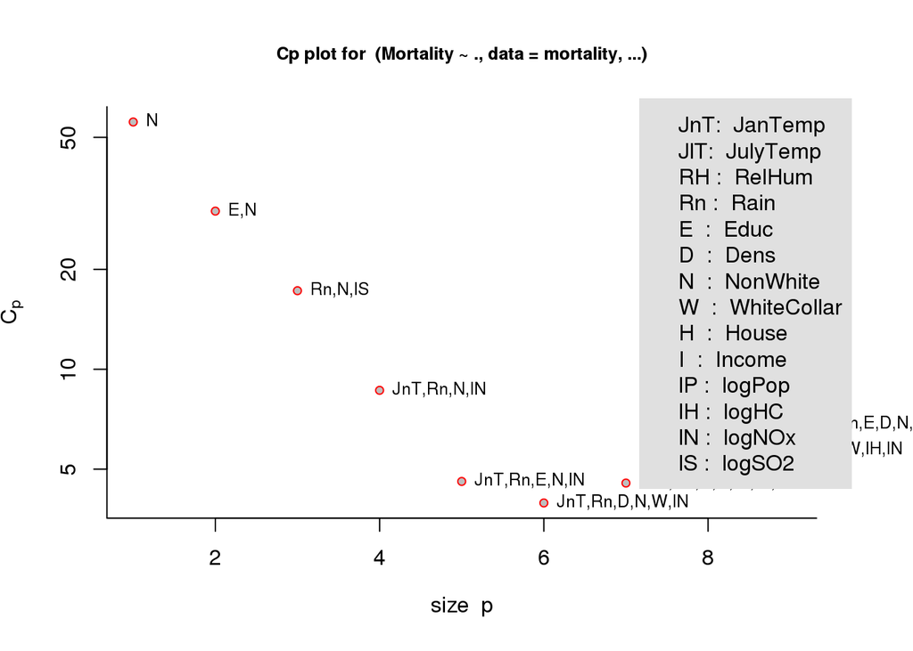

```r
library(leaps)
mortal.alls <- regsubsets(Mortality~., data=mortality, nvmax=9)

source("ftp://stat.ethz.ch/Teaching/maechler/CompStat/cp-plot.R")
p.regsubsets(mortal.alls, cex=0.8, cex.main=.8)
```

# 2. mixture of two normal distributions

Generate the mixture-distributed data:

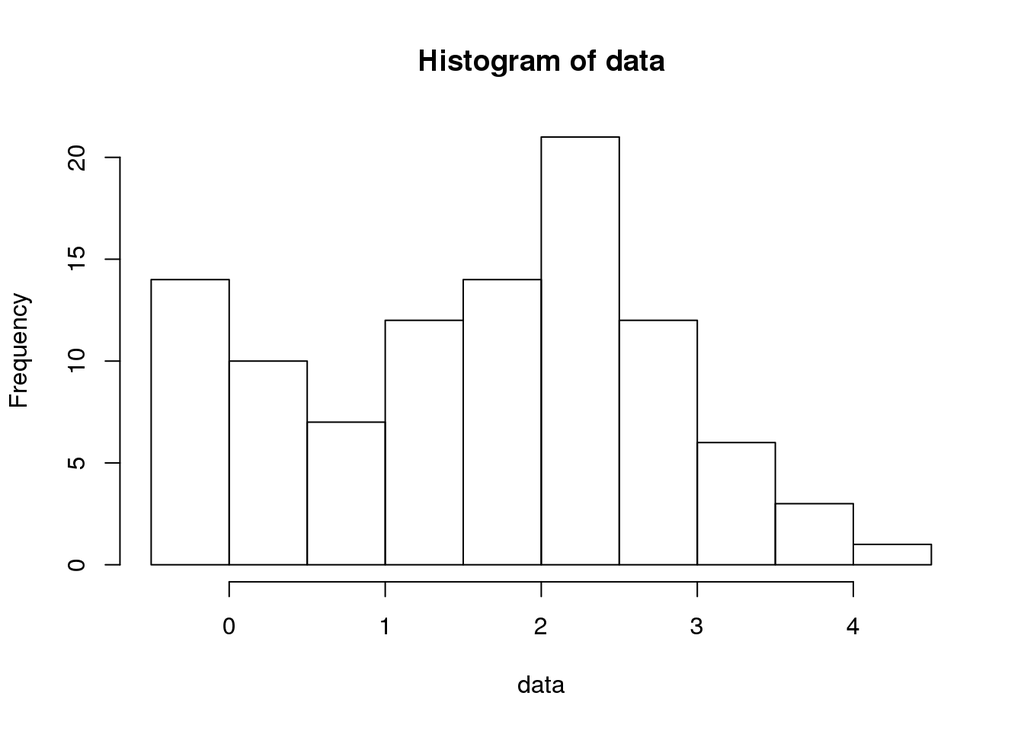

```r
set.seed(1)
data <- numeric(100)
for(i in 1:100){
  p <- runif(1, min=0, max=1)
  if(p<0.2)
    data[i] <- rnorm(1, mean=0, sd=sqrt(0.01))
  else
    data[i] <- rnorm(1, mean=2, sd=1)
}
hist(data)
```

another way to generate data withou loop:

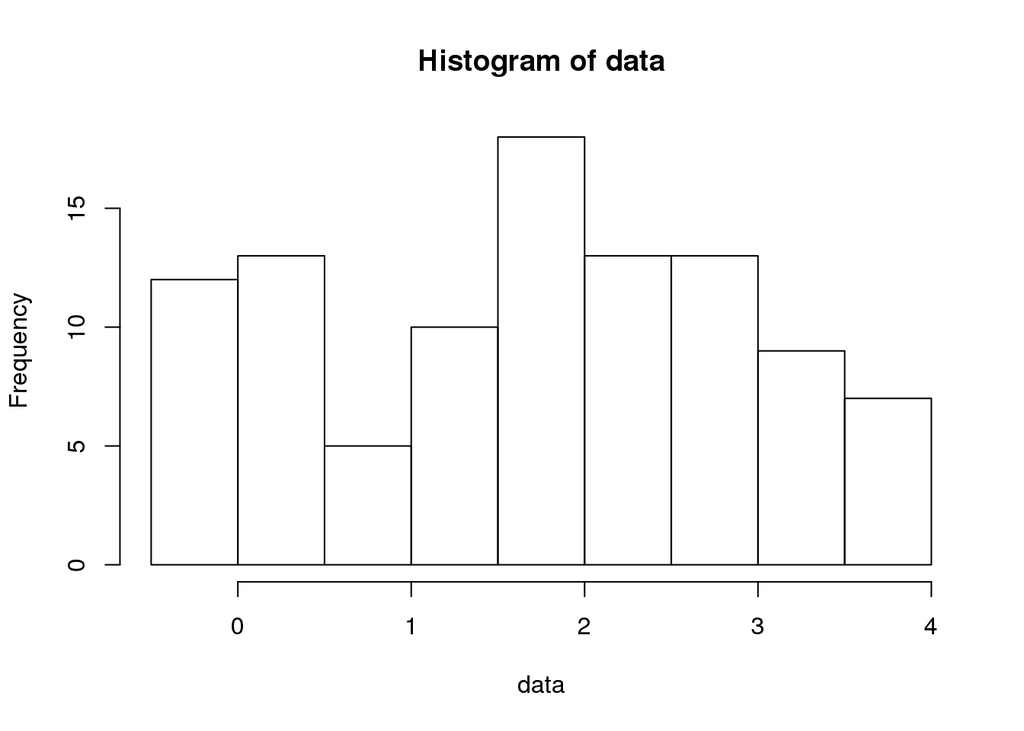

```r
n <- 100
data <- ifelse(runif(n, min=0, max=1)<0.2,rnorm(n, mean=0, sd=sqrt(0.01)), rnorm(n, mean=2, sd=1))
hist(data)
```

## a. best bandwidth with kernel density estimator

The desity estimator is in `density()`.

```r
ke <- density(data, bw=0.1, n=61, from=-1, to = 5)
summary(ke)
```

```
##           Length Class  Mode
## x         61     -none- numeric
## y         61     -none- numeric
## bw         1     -none- numeric
## n          1     -none- numeric
## call       6     -none- call
## data.name  1     -none- character
## has.na     1     -none- logical
```

An estimated plug-in bandwidth is obtained by using `bw ="sj"`.

`ke$x` are the points at which the estimate is to be computed, we can use the average error to estimate the IMSE:

```r
true_density <- 0.2*dnorm(ke$x, mean=0, sd=sqrt(0.01))+0.8*dnorm(ke$x, mean=2, sd=1)
quality <- mean((ke$y-true_density)^2)
```

## b. carry out simulation to evaluate quality of bandwidth

before doing the 200 simulations, create variables to hold the results:

```r
n <- 100
bandwidths <- c(as.list(2^seq(-5,1,0.2)), "sj")
sj <- numeric(200)
qualities <- matrix(ncol=length(bandwidths), nrow=200)
```

For bandwidths we add the “sj” as last element.

```r
for(i in 1:200){ # simulate 200 times
  data <- ifelse(runif(n, min=0, max=1)<0.2,rnorm(n, mean=0, sd=sqrt(0.01)), rnorm(n, mean=2, sd=1))
  for(j in seq_along(bandwidths)){
    ke <- density(data, bw=bandwidths[[j]], n=61, from=-1, to=5)
    qualities[i,j] <- mean((ke$y-true_density)^2)
    if(bandwidths[[j]]=="sj") {sj[i] <- ke$bw}
  }
}
```

find the results:

```r
sj.mean <- mean(sj)
sj.mean
```

```
## [1] 0.2542786
```

```r
results <- apply(qualities, 2, mean) # take col mean
bandwidths[[which.min(results)]]
```

```
## [1] 0.1088188
```

Then plot the bandwith VS quality curve, also plot the selected bandwidth selected with “sj” by a red point:

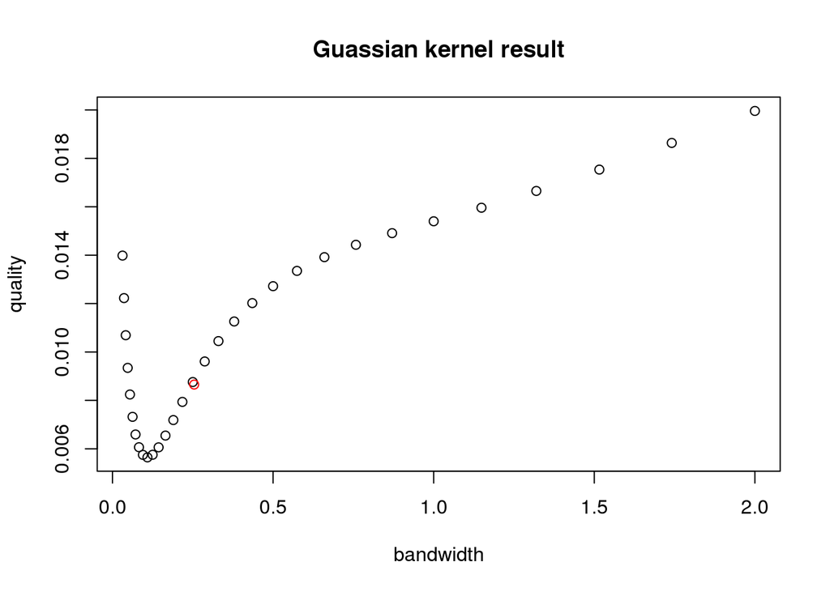

```r
plot(2^seq(-5,1,0.2), results[-length(bandwidths)],xlab="bandwidth", ylab="quality", main="Guassian kernel result")
points(sj.mean, results[length(bandwidths)], col="red")
```